# Homework3

Yuqian Liu

01 March 2018

# Problem 1

**Answer:**

Next, only $I_2$ and $I_3$ contain $\sigma^{2(k+1)}$, to minimize $I_2+I_3$, $\sigma^2$ must be the sample variance of the weighted sample. So
$$\begin{align}
\begin{array}{l}
\sigma^{2(k+1)} =
\frac{\sum\limits_{j = 1}^m \sum\limits_{i = 1}^n p_{ij}^{(k+1)}(y_i-x_i^T\beta_j^{(k+1)}-0)^2}
{\sum\limits_{j = 1}^m \sum\limits_{i = 1}^n p_{ij}^{(k+1)}} \\
=\frac{\sum\limits_{j = 1}^m \sum\limits_{i = 1}^n p_{ij}^{(k+1)}(y_i-x_i^T\beta_j^{(k+1)})^2}{n}
\end{array}
\end{align}$$

Finally, only $I_1$ contains $\pi_j$ in $Q(\Psi|\Psi^{(k)})$, and $\sum\limits_{j = 1}^m \pi_j=1$. By using Lagrange method, construct
$$\begin{align}
\begin{array}{l}
\mathcal{L}(\pi_1,...,\pi_m,\lambda) = Q(\Psi|\Psi^{(k)})-\lambda(\sum\limits_{j = 1}^m \pi_j-1) =0
\end{array}
\end{align}$$

In order to maxmize it, take first derivative of it respect to $\pi_j$ and $\lambda$,
$$\begin{align}
\begin{array}{l}
\mathcal{L}(\pi_1,...,\pi_m,\lambda)_{\pi_j}' =0\\
\mathcal{L}(\pi_1,...,\pi_m,\lambda)_{\lambda}' =0
\end{array}
\end{align}$$

From $\mathcal{L}'_{\pi_j}$,
$$\begin{align}
\sum\limits_{i = 1}^n p_{ij}^{(k+1)}(\frac{1}{\pi_j})-\lambda = 0
\end{align}$$

Thus,
$$\begin{align}
\begin{array}{l}
\pi_j = \frac{\sum\limits_{i = 1}^n p_{ij}^{(k+1)}}{\lambda}\\
\because \sum\limits_{j = 1}^m \pi_j=1\\
\sum\limits_{j = 1}^m \pi_j
= \frac{\sum\limits_{j = 1}^m\sum\limits_{i = 1}^n p_{ij}^{(k+1)}}{\lambda}\\
=\frac{n}{\lambda}\\
\therefore \lambda = n \qquad and \qquad
\pi_j = \frac{\sum\limits_{i = 1}^n p_{ij}^{(k+1)}}{n}
\end{array}
\end{align}$$

# Problem 2

**Answer:**

1. Because $g(x) \propto (2x^{\theta-1}+x^{\theta-1/2})e^{-x}$, the normalizing constant $C$ for g is the constant such that $\int_0 ^\infty g(x) = 1$,
   $$\begin{align}
   C\int_0 ^\infty (2x^{\theta-1}+x^{\theta-1/2})e^{-x}dx = 1
   \end{align}$$
   Thus,
   $$\begin{align}
   \int_0 ^\infty (2x^{\theta-1}+x^{\theta-1/2})e^{-x}dx =
   \int_0 ^\infty 2x^{\theta-1}e^{-x}dx +\int_0 ^\infty x^{\theta-1/2}e^{-x}dx
   \end{align}$$
   By the definition of gamma function,
   $$\begin{align}
   \Gamma(y) = \int_0 ^\infty x^{y-1}e^{-x}dx
   \end{align}$$
   Thus, the integration is equal to,
   $$\begin{align}
   \int_0 ^\infty (2x^{\theta-1}+x^{\theta-1/2})e^{-x}dx =
   2\Gamma(\theta)+\Gamma(\theta+1/2)
   \end{align}$$
   and,
   $$\begin{align}
   C = \frac{1}{2\Gamma(\theta)+\Gamma(\theta+1/2)} \\
   g = C(2x^{\theta-1}+x^{\theta-1/2})e^{-x}
   \end{align}$$
   g is a mixture of Gamma distributions, and rewrite it into

$$\begin{align}
g = 2C*\Gamma(\theta) \frac{x^{\theta-1}e^{-x}}{\Gamma(\theta)}
+ C*\Gamma(\theta+1/2) \frac{x^{\theta-1/2}e^{-x}}{\Gamma(\theta+1/2)}
\end{align}$$

Thus,
$$\begin{align}
g = 2C\Gamma(\theta) Gamma(\theta,1) + C\Gamma(\theta+1/2)Gamma(\theta+1/2,1)
\end{align}$$
The weights for two terms are $\frac{2\Gamma(\theta)}{2\Gamma(\theta)+\Gamma(\theta+1/2)}$ and $\frac{\Gamma(\theta+1/2)}{2\Gamma(\theta)+\Gamma(\theta+1/2)}$ respectively.

2. Using $\theta = 0.5$, thus $\Gamma(\theta)=\Gamma(0.5)=1.772454$ and $\Gamma(\theta+1/2)=\Gamma(1)=1$.
   $$\begin{align}
   C = \frac{1}{2\Gamma(0.5)+\Gamma(1)}=0.2200265 \\
   g(x) = C(2x^{-0.5}+x^0)e^{-x}= C(2x^{-0.5}+1)e^{-x}
   \end{align}$$
   A procedure (pseudo-code) is degined to sample from g with sample size $n=10,000$. The code chunk implementing Inverse transform method is given as follow,

```r
#The number of samples from the mixture distribution
N <- 10000

#Sample N random uniforms U
U <- runif(N)

#Variable to store the samples from the mixture distribution
rand.samples1 <- rep(NA,N)
rand.samples2 <- rep(NA,N)

#Weights
theta1 <- 0.5
theta2 <- 2
C1 <- 1/(2*gamma(theta1)+gamma(theta1+0.5))
c11 <- 2*C1*gamma(theta1)
c12 <- C1*gamma(theta1+0.5)
C2 <- 1/(2*gamma(theta2)+gamma(theta2+0.5))
c21 <- 2*C2*gamma(theta2)
c22 <- C2*gamma(theta2+0.5)

#Sampling from the mixture
for(i in 1:N){
  if(U[i]<c11){
    rand.samples1[i] <- rgamma(1,theta1,rate = 1)
  }else{
    rand.samples1[i] <- rgamma(1,theta1+0.5,rate = 1)
  }
}

for(i in 1:N){
  if(U[i]<c21){
    rand.samples2[i] <- rgamma(1,theta2,rate = 1)
  }else{
    rand.samples2[i] <- rgamma(1,theta2+0.5,rate = 1)
  }
}
```

The kernel density estimation of g from my sample and the true density are plotted in the following figure. There are 2 cases with different $\theta$ values.

**case1:** $\theta= 0.5$

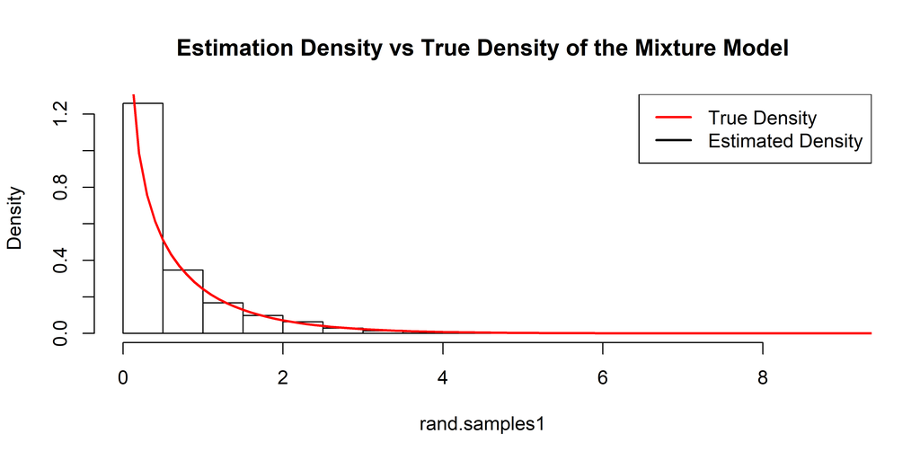

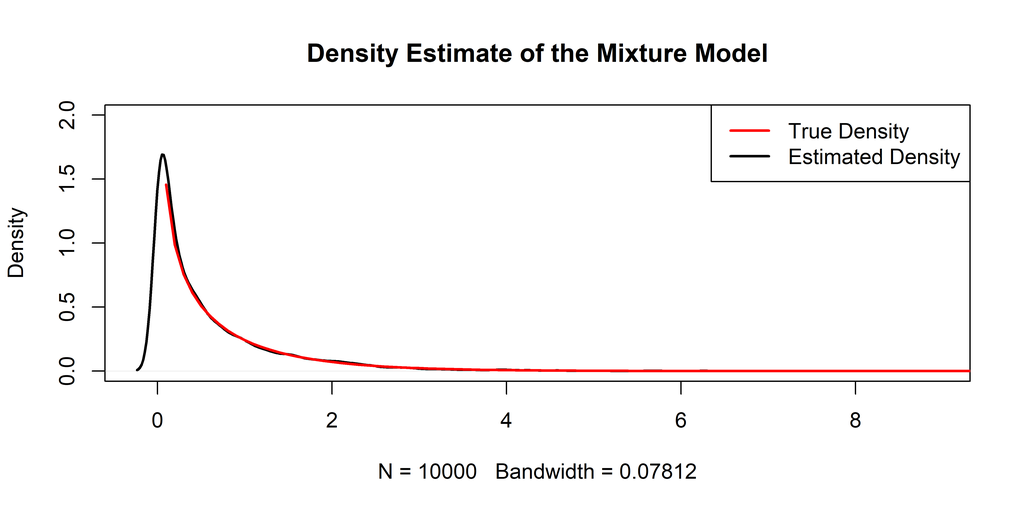

**case2:** $\theta= 2$

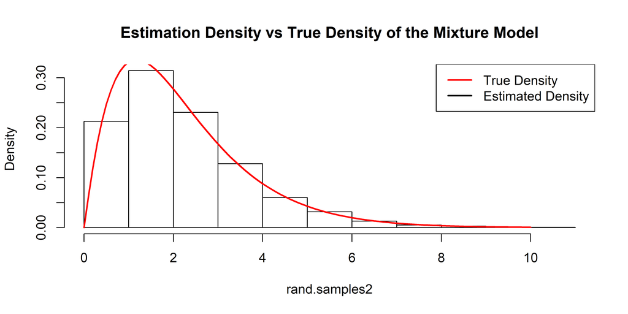

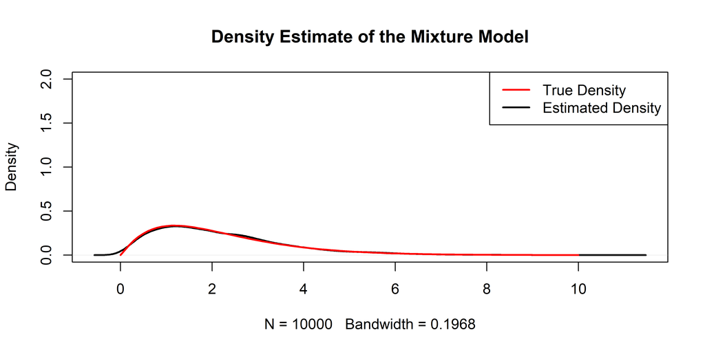

3. A procedure (pseudo-code) is degined to use rejection sampling to sample from f using g as the instrumental distribution, which means $f(x)\le \alpha g(x)$ for all $x\in (0,\infty)$, where $\alpha g(x)$ is the envelope. Since $f(x) \propto \sqrt{4+x}x^{\theta-1}e^{-x}$, the normalizing constant for $f(x)$
   $$\begin{align}
   C'=\frac{1}{\int_0^{\infty} \sqrt{4+x}x^{\theta-1}e^{-x}dx}
   \end{align}$$
   From b), use case 1’s setting $\theta=0.5$. Thus, $C'=0.26666$. By plotting $f(x)$ and $\alpha g(x)$ with different values of $\alpha$. $\alpha = 5$ is picked to set up the envelop.

The code chunk implementing Rejection sampling is given as follow,

```r
# The number of samples from the mixture distribution
N2 <- 10000

# Variable to store the samples from the mixture distribution
rand.samplesF <- rep(NA,N2)

# Check for the normalizing constant
integrandF <- function(x) {sqrt(4+x)*x^(-0.5)*exp(-x)}
C_f <- integrate(integrandF, lower = 0, upper = Inf)
C_f <- C_f$value
C_f <- 1/C_f

# Envelope setting: alpha \in (10,20)
alpha <- 5
theta <- 0.5
C <- 1/(2*gamma(theta)+gamma(theta+0.5))
c1 <- 2*C*gamma(theta)
c2 <- C*gamma(theta+0.5)
g_x <- function(x) {c1*dgamma(x,theta,1) + c2*dgamma(x,theta+0.5,1)}

# Plot f and envelop
x_value <- seq(0,5,.05)
F <- function(x) {sqrt(4+x)*x^(0.5-1)*exp(-x)}
truthF <- C_f*F(x_value)
#plot(x_value,truthF,col="red",lwd=2)
truthG <- c1*dgamma(x_value,theta,1) + c2*dgamma(x_value,theta+0.5,1)
Envelop <- alpha*truthG
#lines(x_value,Envelop,col="blue",lwd=2)

#Rejection Sampling from the envelop
for (i in 1:N2) {
  while (TRUE) {
    U <- runif(1)
    if(U < c1){
      cand <- rgamma(1,theta,rate = 1)
    }else{
      cand <- rgamma(1,theta+0.5,rate = 1)
    }
    ratio <- F(cand)/(alpha*g_x(cand))
    if (U < ratio) break
  }
  rand.samplesF[i] <- cand
}
```

The the estimated density of a random sample generated by my procedure and f are plotted in the following figure.

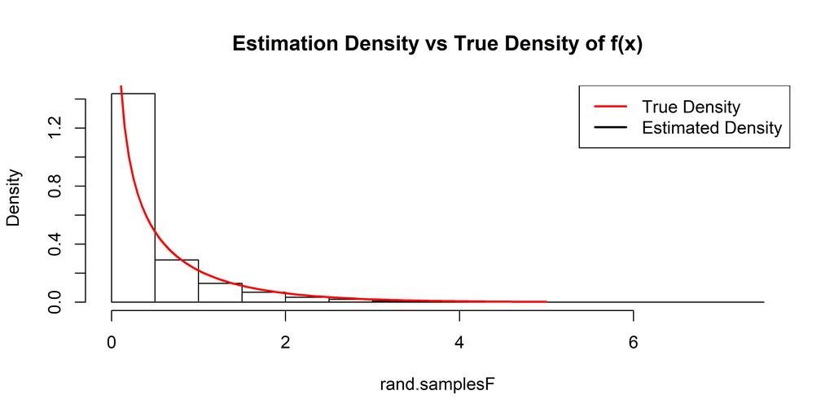

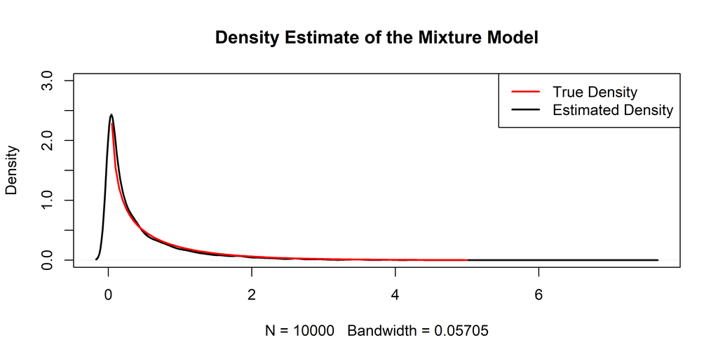

# Problem 3

**Answer:**

1. Design a mixture of Beta distributions $g(x)$ as the instrumental density to draw sample from $f(x)$, where $f(x)$ is a pbability density on $(0,1)$ such that
   $$\begin{align}
   f(x) \propto q(x) = \frac{x^{\theta-1}}{1+x^2} +\sqrt{(2+x^2)}(1-x)^{\beta-1}, 0<x<1
   \end{align}$$
   .

The instrumental density $g(x)$ have the form $\sum_{k=1}^{m}p_kg_k(x)$, where $p_k$ are weights and $g_k$ are densities of Beta distribution. Comparing to Beta$(\theta,\beta)$ density definition,
$$\begin{align}
z(x) = \frac{x^{\theta-1}(1-x)^{\beta-1}}{B(\theta,\beta)}
\end{align}$$
Rewite $q(x)$,
$$\begin{align}
q(x) = \frac{1}{1+x^2} x^{\theta-1}(1-x)^{0} +\sqrt{(2+x^2)}x^0(1-x)^{\beta-1}
\end{align}$$
Since $x\in (0,1)$
$$\begin{align}
q(x) \leq x^{\theta-1}(1-x)^{0} +\sqrt{3}x^0(1-x)^{\beta-1}
= x^{\theta-1} +\sqrt{3}(1-x)^{\beta-1}
\end{align}$$
My choice of the mixture model is,
$$\begin{align}
g(x) = p_1g_1(x) +p_2g_2(x),
\end{align}$$
where
$$\begin{align}
\begin{array}{l}
g_1(x) = \frac{x^{\theta-1}(1-x)^{0}}{B(\theta,1)}
=\frac{x^{\theta-1}}{B(\theta,1)} = Beta(\theta,1)\\
g_2(x) = \frac{x^0(1-x)^{\beta-1}}{B(1,\beta)}
= \frac{(1-x)^{\beta-1}}{B(1,\beta)} = Beta(1,\beta)\\
p_1=p_2=0.5 \qquad and \qquad \sum p_k = 1\\
\end{array}
\end{align}$$
In order to satisfy
$$\begin{align}
q(x) \leq x^{\theta-1} +\sqrt{3}(1-x)^{\beta-1} \leq \alpha g(x),
\end{align}$$
the choice of $\alpha$ is shown as follow.
$$\begin{align}
\begin{array}{l}
\alpha g(x) = 0.5\alpha( g_1(x) + g_2(x)) \\
= 0.5\alpha( \frac{x^{\theta-1}}{B(\theta,1)} +
\frac{(1-x)^{\beta-1}}{B(1,\beta)}) \\
= 0.5\alpha \theta x^{\theta-1} + 0.5\alpha \beta (1-x)^{\beta-1},
\end{array}
\end{align}$$
where
$$\begin{align}
1\leq 0.5\alpha \theta \qquad and \qquad \sqrt{3} \leq 0.5\alpha \beta
\end{align}$$
Solve for $\alpha$,
$$\begin{align}
\frac{2}{\theta}\leq \alpha \qquad and \qquad \frac{2\sqrt{3}}{\beta} \leq \alpha
\end{align}$$
This means $\alpha=max(\frac{2}{\theta},\frac{2\sqrt{3}}{\beta})$ based on target function’s parameters.

The code chunk implementing Rejection sampling is given as follow,

```r
#The number of samples from the mixture distribution
N <- 10000

#Variable to store the samples from the mixture distribution
rand.samplesF <- rep(NA,N)

#Setup parameters
theta <- 7
beta <- 5

#check for the normalizing constant
integrandq <- function(x) {((x^(theta-1))/(1+x^2))+sqrt(2+x^2)*(1-x)^(beta-1)}
C_f <- integrate(integrandq, lower = 0, upper = 1)
C_f <- C_f$value
C_f <- 1/C_f

#envelope setting (10,20)
alpha <- max(2/theta,2*sqrt(3)/beta)
c1 <- 0.5
c2 <- 0.5
g_x <- function(x) {c1*dbeta(x,theta,1) + c2*dbeta(x,1,beta)}

#plot f and envelope
x_value3 <- seq(0,1,.01)
truthF <- C_f*integrandq(x_value3)
#plot(x_value3,truthF,col="red",lwd=2)
truthG <- g_x(x_value3)
Envelop <- alpha*truthG
#lines(x_value3,Envelop,col="blue",lwd=2)

#Rejection Sampling from the envelop
for (i in 1:N) {
  while (TRUE) {
    U <- runif(1)
    if(U < c1){
      cand <- rbeta(1,theta,1)
    }else{
      cand <- rbeta(1,1,beta)
    }
    ratio <- F(cand)/(alpha*g_x(cand))
    rejection <- runif(1)
    if (rejection < ratio) break
  }
  rand.samplesF[i] <- cand
}
```

The the estimated density of a random sample generated by my procedure and f are plotted in the following figure.

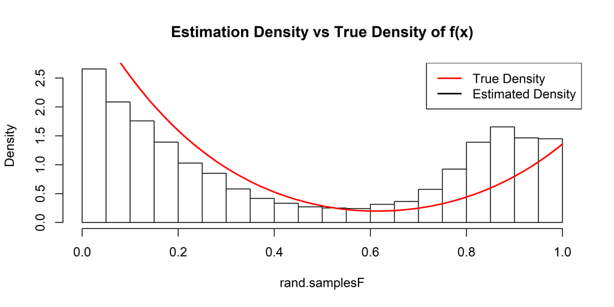

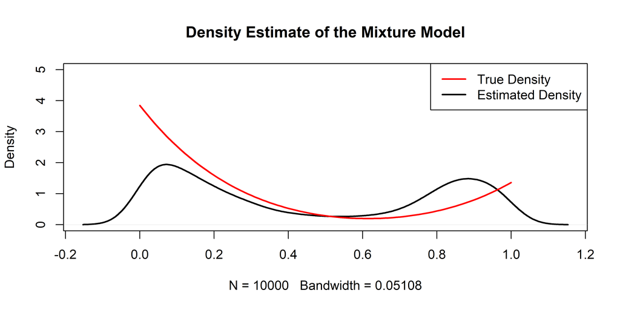

2. $f(x)$ can also be sampled using rejection sampling, by dealing with two components $\frac{x^{\theta-1}}{1+x^2}$ and $\sqrt{(2+x^2)}(1-x)^{\beta-1}$ separately using individual Beta distributions.

From a), two Beta distribution have been picked up.
$$\begin{align}
\begin{array}{l}
g(x)=\alpha_1 g_1(x) +\alpha_2 g_2(x) \\
q(x) \leq x^{\theta-1} +\sqrt{3}(1-x)^{\beta-1} \leq \alpha g(x)
\end{array}
\end{align}$$
Thus,
$$\begin{align}
\begin{array}{l}
x^{\theta-1} \leq \alpha_1 g_1(x) \qquad and \qquad
\sqrt{3}(1-x)^{\beta-1} \leq \alpha_2 g_2(x) \\
\frac{1}{\theta}\leq \alpha_1 \qquad and \qquad \frac{\sqrt{3}}{\beta} \leq \alpha_2
\end{array}
\end{align}$$
Set weighted $\lambda = \frac{\frac{1}{\theta}}{\frac{1}{\theta}+\frac{\sqrt{3}}{\beta}}$.

The code chunk implementing Rejection sampling is given as follow,

```r
#The number of samples from the mixture distribution
N <- 10000

#Variable to store the samples from the mixture distribution
rand.samplesF <- rep(NA,N)

#Setup parameters
theta <- 7
beta <- 5
#theta <- 9
#beta <- 5

#check for the normalizing constant
integrandq <- function(x) {((x^(theta-1))/(1+x^2))+sqrt(2+x^2)*(1-x)^(beta-1)}
C_f <- integrate(integrandq, lower = 0, upper = 1)
C_f <- C_f$value
C_f <- 1/C_f

#envelope setting (10,20)
alpha1 <- 1/theta
alpha2 <- sqrt(3)/beta
g_x <- function(x) {dbeta(x,theta,1) + dbeta(x,1,beta)}
Envelop <- function(x) {alpha1*dbeta(x,theta,1) + alpha2*dbeta(x,1,beta)}

#plot f
x_value3 <- seq(0,1,.01)
truthF <- C_f*integrandq(x_value3)
#plot(x_value3,truthF,col="red",lwd=2)
truthG <- g_x(x_value3)
EnvelopG <- Envelop(x_value3)
#lines(x_value3,EnvelopG,col="blue",lwd=2)

#Rejection Sampling from the envelop
for (i in 1:N) {
  while (TRUE) {
    U <- runif(1)
    if(U < alpha1/(alpha1+alpha2)){
      cand <- rbeta(1,theta,1)
    }else{
      cand <- rbeta(1,1,beta)
    }
    ratio <- F(cand)/(Envelop(cand))
    rejection <- runif(1)
    if (rejection < ratio) break
  }
  rand.samplesF[i] <- cand
}
```

The the estimated density of a random sample generated by my procedure and f are plotted in the following figure.

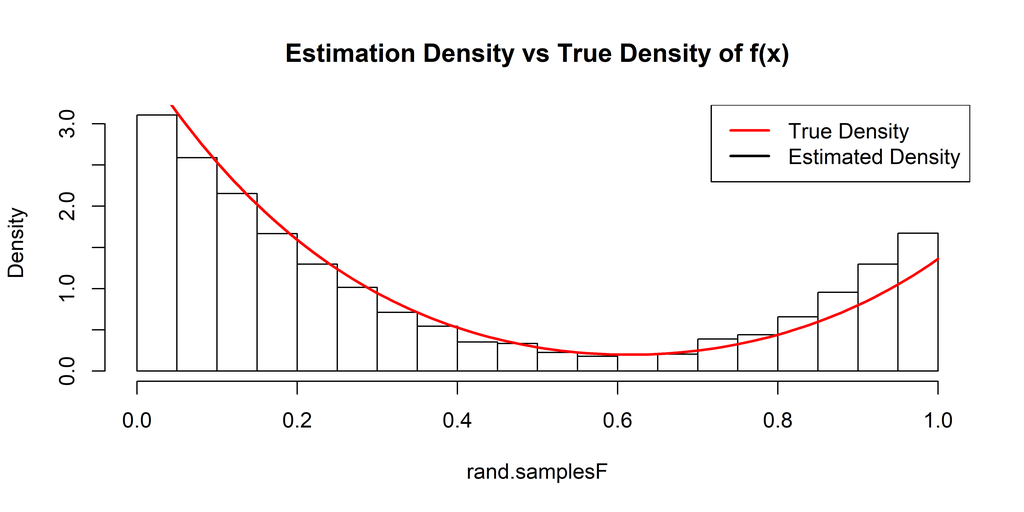

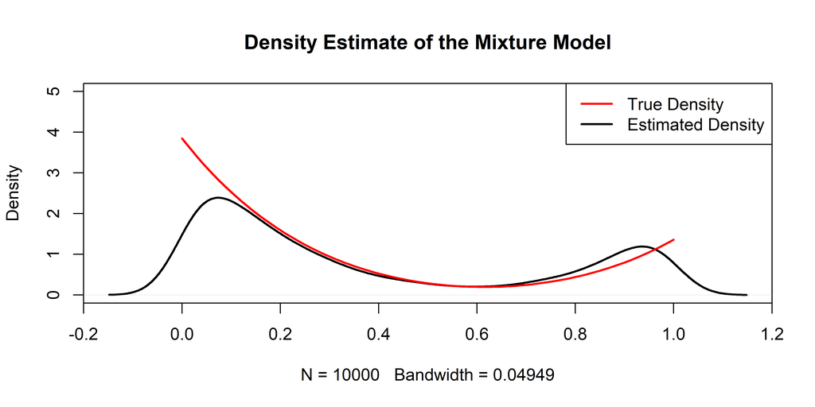